# RNAseq experiment growth and metabolites

Thoenen et al. AMPO formation

Lisa Thönen, updated by Christine Pestalozzi

2024-05-13

Here we report the growth and metabolite data of the bacterial cultures used for the transcriptome experiment. Bacteria were grown for 16 hours in a laboratory shaker and one plate was grown in a tecan plate reader and used to analyse the growth data.

# Setup

Set working directory to source file location.

# Bacterial growth

Read in metadata Additional samples that are not relevant to this study were measured in the same plate. These are not annotated.

Read in raw data, combine with metadata and calculate change in absorbance relative to start

Plot raw data growth curves 16 hours

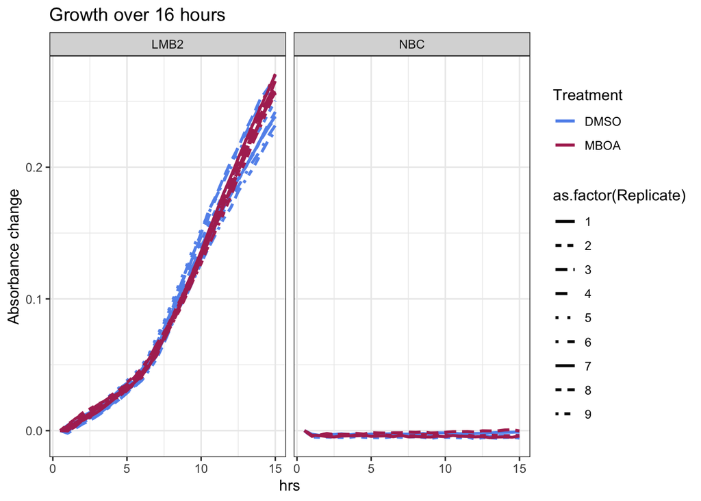

Maximal growth 16 hours

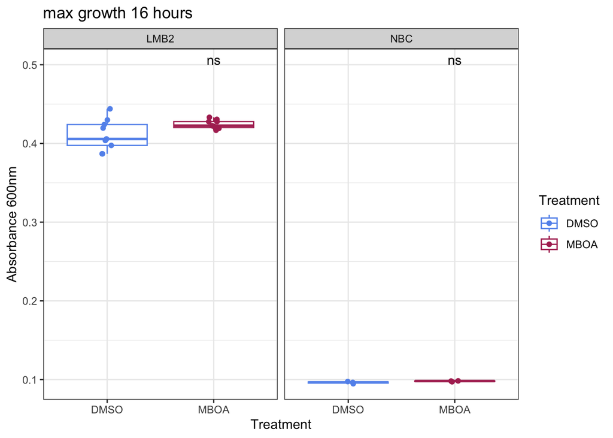

Area under the curve of 16 hrs of growth

Fig S9a: growth LMB2 (AUC over 16 hours)

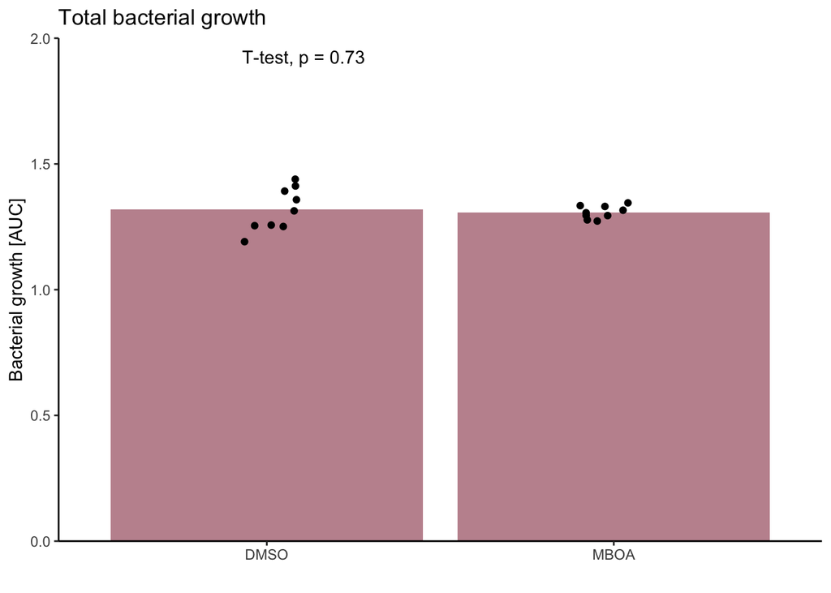

Data single plates

remove samples which did not grew

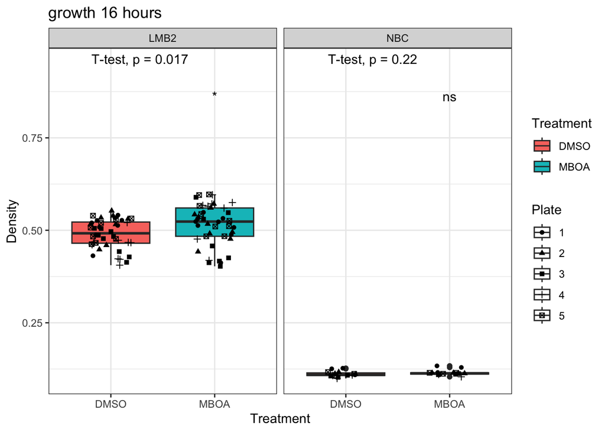

# Bacterial metabolites

Read in metadata and quantification of BX after 16 h of growth in half TSB supplemented with 500 uM MBOA or DMSO. Media controls taken at the beginning are included. Additional samples not relevant to this study were run at the same time. These are not shown here.

Plot concentrations measured after 16 h for samples of LMB2, no bacteria control (NBC) and media controls taken at start of experiment (T0)

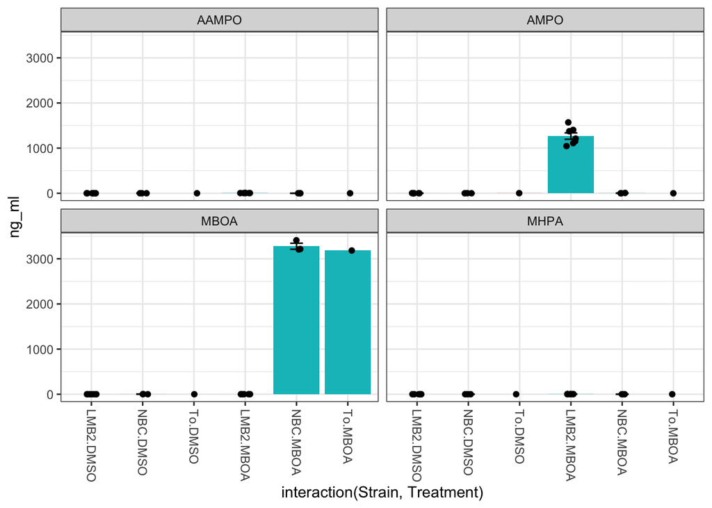

Plot measurements only for samples supplemented with MBOA at the beginning

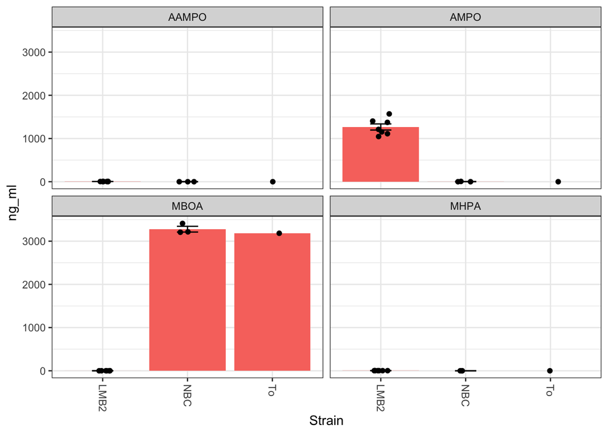

Fig S9b) Supplementary figure metabolisation of MBOA after 16 h

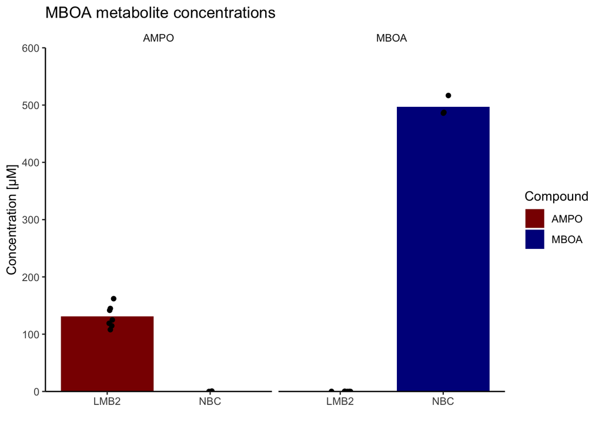